# Introduction to Neural Networks: Bank Churn prediction

[github link for Jupyter Notebook](https://github.com/sureshdpawar/deep-learning-back-churn-project-4/tree/master)

## Problem Statement

In the competitive landscape of banking and financial services, customer retention emerges as a critical challenge, encapsulated by the phenomenon of 'Customer Churn'—the departure of clients to rival institutions. Understanding the myriad factors that drive a customer's decision to leave is crucial for strategic service enhancement. This knowledge enables management to focus their efforts on targeted improvements, prioritizing elements of the service that most significantly impact customer loyalty and decision-making. Addressing this issue not only requires identifying these key factors but also developing actionable strategies that can mitigate churn, thereby ensuring sustained customer engagement and loyalty.

### Context

Businesses like banks which provide service have to worry about problem of 'Customer Churn' i.e. customers leaving and joining another service provider. It is important to understand which aspects of the service influence a customer's decision in this regard. Management can concentrate efforts on improvement of service, keeping in mind these priorities.

### Objective

You as a Data scientist with the bank need to build a neural network based classifier that can determine whether a customer will leave the bank or not in the next 6 months.

### Data Dictionary:

- CustomerId: Unique ID which is assigned to each customer
- Surname: Last name of the customer
- CreditScore: It defines the credit history of the customer.
- Geography: A customer’s location
- Gender: It defines the Gender of the customer
- Age: Age of the customer
- Tenure: Number of years for which the customer has been with the bank
- NumOfProducts: refers to the number of products that a customer has purchased through the bank.
- Balance: Account balance
- HasCrCard: It is a categorical variable which decides whether the customer has credit card or not.
- EstimatedSalary: Estimated salary
- isActiveMember: Is is a categorical variable which decides whether the customer is active member of the bank or not ( Active member in the sense, using bank products regularly, making transactions etc )
- Exited : whether or not the customer left the bank within six month. It can take two values **0=No ( Customer did not leave the bank )** 1=Yes ( Customer left the bank )

## Importing necessary libraries

```python
!pip install tensorflow
```

```python
!pip install scikeras
```

```python
!pip install imbalanced-learn tensorflow scikit-learn
```

```python
import numpy as np
import pandas as pd
import tensorflow as tf
import keras

import matplotlib.pyplot as plt
%matplotlib inline

import seaborn as sns
sns.set(palette="Set2")

import plotly.express as px

from sklearn.model_selection import train_test_split
from sklearn.metrics import (accuracy_score, f1_score,average_precision_score, confusion_matrix,
                             average_precision_score, precision_score, recall_score, roc_auc_score, )
from mlxtend.plotting import plot_confusion_matrix

from tensorflow.keras.models import Sequential
from tensorflow.keras.layers import Dense, Activation
from tensorflow.keras.callbacks import EarlyStopping
from tensorflow.keras.optimizers import Adam
from tensorflow.keras.layers import Dropout
from scikeras.wrappers import KerasRegressor
from sklearn.model_selection import GridSearchCV

#from tensorflow.keras.wrappers.scikit_learn import KerasClassifier
from sklearn.metrics import classification_report, confusion_matrix
#from sklearn.metrics import plot_roc_curve, roc_auc_score, roc_curve
from sklearn.model_selection import cross_val_score, cross_validate
from sklearn.model_selection import GridSearchCV

from sklearn.preprocessing import LabelEncoder, MinMaxScaler, StandardScaler

from tensorflow.keras import backend

from xgboost import XGBClassifier, plot_importance
from imblearn.over_sampling import SMOTE

from sklearn import preprocessing
import sklearn
from sklearn.metrics import explained_variance_score, mean_squared_error, r2_score, mean_absolute_error
from sklearn.model_selection import train_test_split
```

## Loading the dataset

```python
from google.colab import drive
drive.mount('/content/drive')
%cd /content/drive/MyDrive/AI-ML
df = pd.read_csv("Churn.csv")
dataset=df.copy()
```

```
/content/drive/MyDrive/AI-ML
```

## Data Overview

```python
dataset.head()
```

|  | RowNumber | CustomerId | Surname | CreditScore | Geography | Gender | Age | Tenure | Balance | NumOfProducts | HasCrCard | IsActiveMember | EstimatedSalary | Exited |
| --- | --- | --- | --- | --- | --- | --- | --- | --- | --- | --- | --- | --- | --- | --- |
| 0 | 1 | 15634602 | Hargrave | 619 | France | Female | 42 | 2 | 0.00 | 1 | 1 | 1 | 101348.88 | 1 |
| 1 | 2 | 15647311 | Hill | 608 | Spain | Female | 41 | 1 | 83807.86 | 1 | 0 | 1 | 112542.58 | 0 |
| 2 | 3 | 15619304 | Onio | 502 | France | Female | 42 | 8 | 159660.80 | 3 | 1 | 0 | 113931.57 | 1 |
| 3 | 4 | 15701354 | Boni | 699 | France | Female | 39 | 1 | 0.00 | 2 | 0 | 0 | 93826.63 | 0 |
| 4 | 5 | 15737888 | Mitchell | 850 | Spain | Female | 43 | 2 | 125510.82 | 1 | 1 | 1 | 79084.10 | 0 |

```python
dataset.shape
```

```
(10000, 14)
```

```python
dataset.describe().T
```

|  | count | mean | std | min | 25% | 50% | 75% | max |
| --- | --- | --- | --- | --- | --- | --- | --- | --- |
| RowNumber | 10000.0 | 5.000500e+03 | 2886.895680 | 1.00 | 2500.75 | 5.000500e+03 | 7.500250e+03 | 10000.00 |
| CustomerId | 10000.0 | 1.569094e+07 | 71936.186123 | 15565701.00 | 15628528.25 | 1.569074e+07 | 1.575323e+07 | 15815690.00 |
| CreditScore | 10000.0 | 6.505288e+02 | 96.653299 | 350.00 | 584.00 | 6.520000e+02 | 7.180000e+02 | 850.00 |
| Age | 10000.0 | 3.892180e+01 | 10.487806 | 18.00 | 32.00 | 3.700000e+01 | 4.400000e+01 | 92.00 |
| Tenure | 10000.0 | 5.012800e+00 | 2.892174 | 0.00 | 3.00 | 5.000000e+00 | 7.000000e+00 | 10.00 |
| Balance | 10000.0 | 7.648589e+04 | 62397.405202 | 0.00 | 0.00 | 9.719854e+04 | 1.276442e+05 | 250898.09 |
| NumOfProducts | 10000.0 | 1.530200e+00 | 0.581654 | 1.00 | 1.00 | 1.000000e+00 | 2.000000e+00 | 4.00 |
| HasCrCard | 10000.0 | 7.055000e-01 | 0.455840 | 0.00 | 0.00 | 1.000000e+00 | 1.000000e+00 | 1.00 |
| IsActiveMember | 10000.0 | 5.151000e-01 | 0.499797 | 0.00 | 0.00 | 1.000000e+00 | 1.000000e+00 | 1.00 |
| EstimatedSalary | 10000.0 | 1.000902e+05 | 57510.492818 | 11.58 | 51002.11 | 1.001939e+05 | 1.493882e+05 | 199992.48 |
| Exited | 10000.0 | 2.037000e-01 | 0.402769 | 0.00 | 0.00 | 0.000000e+00 | 0.000000e+00 | 1.00 |

```python
dataset.info()
```

```
<class 'pandas.core.frame.DataFrame'>
RangeIndex: 10000 entries, 0 to 9999
Data columns (total 14 columns):
 #   Column           Non-Null Count  Dtype
---  ------           --------------  -----
 0   RowNumber        10000 non-null  int64
 1   CustomerId       10000 non-null  int64
 2   Surname          10000 non-null  object
 3   CreditScore      10000 non-null  int64
 4   Geography        10000 non-null  object
 5   Gender           10000 non-null  object
 6   Age              10000 non-null  int64
 7   Tenure           10000 non-null  int64
 8   Balance          10000 non-null  float64
 9   NumOfProducts    10000 non-null  int64
 10  HasCrCard        10000 non-null  int64
 11  IsActiveMember   10000 non-null  int64
 12  EstimatedSalary  10000 non-null  float64
 13  Exited           10000 non-null  int64
dtypes: float64(2), int64(9), object(3)
memory usage: 1.1+ MB
```

```python
#get the size of dataframe
print ("Rows     : " , dataset.shape[0])  #get number of rows/observations
print ("Columns  : " , dataset.shape[1]) #get number of columns
print ("#"*40,"\n","Features : \n\n", dataset.columns.tolist()) #get name of columns/features
print ("#"*40,"\nMissing values :\n\n", dataset.isnull().sum().sort_values(ascending=False))
print( "#"*40,"\nPercent of missing :\n\n", round(dataset.isna().sum() / dataset.isna().count() * 100, 2)) # looking at columns with most Missing Values
print ("#"*40,"\nUnique values :  \n\n", dataset.nunique())  #  count of unique values
```

```
Rows     :  10000
Columns  :  14
########################################
 Features :

 ['RowNumber', 'CustomerId', 'Surname', 'CreditScore', 'Geography', 'Gender', 'Age', 'Tenure', 'Balance', 'NumOfProducts', 'HasCrCard', 'IsActiveMember', 'EstimatedSalary', 'Exited']
########################################
Missing values :

 RowNumber          0
CustomerId         0
Surname            0
CreditScore        0
Geography          0
Gender             0
Age                0
Tenure             0
Balance            0
NumOfProducts      0
HasCrCard          0
IsActiveMember     0
EstimatedSalary    0
Exited             0
dtype: int64
########################################
Percent of missing :

 RowNumber          0.0
CustomerId         0.0
Surname            0.0
CreditScore        0.0
Geography          0.0
Gender             0.0
Age                0.0
Tenure             0.0
Balance            0.0
NumOfProducts      0.0
HasCrCard          0.0
IsActiveMember     0.0
EstimatedSalary    0.0
Exited             0.0
dtype: float64
########################################
Unique values :

 RowNumber          10000
CustomerId         10000
Surname             2932
CreditScore          460
Geography              3
Gender                 2
Age                   70
Tenure                11
Balance             6382
NumOfProducts          4
HasCrCard              2
IsActiveMember         2
EstimatedSalary     9999
Exited                 2
dtype: int64
```

```python
dataset.drop(["RowNumber", "CustomerId", "Surname"], axis=1, inplace=True)
```

```python
dataset.head()
```

|  | CreditScore | Geography | Gender | Age | Tenure | Balance | NumOfProducts | HasCrCard | IsActiveMember | EstimatedSalary | Exited |
| --- | --- | --- | --- | --- | --- | --- | --- | --- | --- | --- | --- |
| 0 | 619 | France | Female | 42 | 2 | 0.00 | 1 | 1 | 1 | 101348.88 | 1 |
| 1 | 608 | Spain | Female | 41 | 1 | 83807.86 | 1 | 0 | 1 | 112542.58 | 0 |
| 2 | 502 | France | Female | 42 | 8 | 159660.80 | 3 | 1 | 0 | 113931.57 | 1 |
| 3 | 699 | France | Female | 39 | 1 | 0.00 | 2 | 0 | 0 | 93826.63 | 0 |
| 4 | 850 | Spain | Female | 43 | 2 | 125510.82 | 1 | 1 | 1 | 79084.10 | 0 |

```python
category_col = ['Geography', 'Gender']
```

```python
for column in category_col:
    print(dataset[column].value_counts())
    print("#" * 40)
```

```
France     5014
Germany    2509
Spain      2477
Name: Geography, dtype: int64
########################################
Male      5457
Female    4543
Name: Gender, dtype: int64
########################################
```

```python
dataset.info()
```

```
<class 'pandas.core.frame.DataFrame'>
RangeIndex: 10000 entries, 0 to 9999
Data columns (total 11 columns):
 #   Column           Non-Null Count  Dtype
---  ------           --------------  -----
 0   CreditScore      10000 non-null  int64
 1   Geography        10000 non-null  object
 2   Gender           10000 non-null  object
 3   Age              10000 non-null  int64
 4   Tenure           10000 non-null  int64
 5   Balance          10000 non-null  float64
 6   NumOfProducts    10000 non-null  int64
 7   HasCrCard        10000 non-null  int64
 8   IsActiveMember   10000 non-null  int64
 9   EstimatedSalary  10000 non-null  float64
 10  Exited           10000 non-null  int64
dtypes: float64(2), int64(7), object(2)
memory usage: 859.5+ KB
```

```python
dataset.head()
```

|  | CreditScore | Geography | Gender | Age | Tenure | Balance | NumOfProducts | HasCrCard | IsActiveMember | EstimatedSalary | Exited |
| --- | --- | --- | --- | --- | --- | --- | --- | --- | --- | --- | --- |
| 0 | 619 | France | Female | 42 | 2 | 0.00 | 1 | 1 | 1 | 101348.88 | 1 |
| 1 | 608 | Spain | Female | 41 | 1 | 83807.86 | 1 | 0 | 1 | 112542.58 | 0 |
| 2 | 502 | France | Female | 42 | 8 | 159660.80 | 3 | 1 | 0 | 113931.57 | 1 |
| 3 | 699 | France | Female | 39 | 1 | 0.00 | 2 | 0 | 0 | 93826.63 | 0 |
| 4 | 850 | Spain | Female | 43 | 2 | 125510.82 | 1 | 1 | 1 | 79084.10 | 0 |

```python
dataset.describe(include=object).T
```

|  | count | unique | top | freq |
| --- | --- | --- | --- | --- |
| Geography | 10000 | 3 | France | 5014 |
| Gender | 10000 | 2 | Male | 5457 |

```python
dataset['Exited'].value_counts()
```

```
0    7963
1    2037
Name: Exited, dtype: int64
```

**Observations on data overview**

- The dataset has 10000 rows and 14 columns
- There are 11 numerical columns and 3 non numerical columns, out of which 2 are categorical columns like Geography and Gender
- There are no missing values in dataset
- There are unique valies for some features
- We have dropped three columns "RowNumber", "CustomerId", "Surname" becuse they ae not reuired for model building
- The unique values for categorical variable Geography are 3 which are France, Germany, Spain and max frequency is for France with 5014
- The unique values for categorical variable Gender are 2 which are Male anf Female and max frequency is for Male with 5457

**Insights from describe of dataset**

Credit Score:

The average credit score among customers is 650.53 with a standard deviation of 96.65, ranging from 350 to 850. This indicates a wide range of creditworthiness among the customers, with most scores clustered around the mean.

Age:

The average age is approximately 39 years, with a standard deviation of 10.49, indicating a middle-aged customer base. The age range is 18 to 92 years, showing diversity in customer demographics.

Tenure:

On average, customers have been with the institution for 5 years, with tenures ranging from 0 to 10 years. This suggests a mix of new and long-term customers.

Balance:

The average account balance is roughly 76,485.89, with a large standard deviation of 62,397.41, indicating significant variability in customer balances. Notably, 25% of customers have a zero balance, which could imply either new accounts or inactive ones.

NumOfProducts:

Customers hold an average of 1.53 products from the institution, with the number of products ranging from 1 to 4. This suggests most customers use a limited range of the institution's offerings.

HasCrCard:

70.55% of customers have a credit card issued by the institution, indicating a high penetration of the institution's credit card among its customers.

IsActiveMember:

51.51% of the customers are marked as active, highlighting that slightly more than half of the customer base is engaged with the institution's products or services.

EstimatedSalary:

The average estimated salary of customers is around 100,090.20, with a broad range (min 11.58 to max 199,992.48), suggesting a wide spectrum of income levels among the customer base.

Exited (Customer Churn):

20.37% of customers have exited, indicating a churn rate that the institution may want to investigate further to understand and potentially reduce.

## Exploratory Data Analysis

- EDA is an important part of any project involving data.
- It is important to investigate and understand the data better before building a model with it.
- A few questions have been mentioned below which will help you approach the analysis in the right manner and generate insights from the data.
- A thorough analysis of the data, in addition to the questions mentioned below, should be done.

**Questions**:

1. What is the distribution of the credit score of customers? Are there any noticeable patterns or outliers in the distribution?
2. How many active members are there with the bank?
3. How are the different customer attributes correlated to each other?
4. Who is churning more when compared to males and females?
5. Customers from which geographical part are churning more?

```python
# function to plot a boxplot and a histogram along the same scale.


def histogram_boxplot(data, feature, figsize=(12, 7), kde=False, bins=None):
    """
    Boxplot and histogram combined

    data: dataframe
    feature: dataframe column
    figsize: size of figure (default (12,7))
    kde: whether to the show density curve (default False)
    bins: number of bins for histogram (default None)
    """
    f2, (ax_box2, ax_hist2) = plt.subplots(
        nrows=2,  # Number of rows of the subplot grid= 2
        sharex=True,  # x-axis will be shared among all subplots
        gridspec_kw={"height_ratios": (0.25, 0.75)},
        figsize=figsize,
    )  # creating the 2 subplots
    sns.boxplot(
        data=data, x=feature, ax=ax_box2, showmeans=True, color="violet"
    )  # boxplot will be created and a triangle will indicate the mean value of the column
    sns.histplot(
        data=data, x=feature, kde=kde, ax=ax_hist2, bins=bins, palette="winter"
    ) if bins else sns.histplot(
        data=data, x=feature, kde=kde, ax=ax_hist2
    )  # For histogram
    ax_hist2.axvline(
        data[feature].mean(), color="green", linestyle="--"
    )  # Add mean to the histogram
    ax_hist2.axvline(
        data[feature].median(), color="black", linestyle="-"
    )  # Add median to the histogram
```

```python
# function to create labeled barplots


def labeled_barplot(data, feature, perc=False, n=None):
    """
    Barplot with percentage at the top

    data: dataframe
    feature: dataframe column
    perc: whether to display percentages instead of count (default is False)
    n: displays the top n category levels (default is None, i.e., display all levels)
    """

    total = len(data[feature])  # length of the column
    count = data[feature].nunique()
    if n is None:
        plt.figure(figsize=(count + 1, 5))
    else:
        plt.figure(figsize=(n + 1, 5))

    plt.xticks(rotation=90, fontsize=15)
    ax = sns.countplot(
        data=data,
        x=feature,
        palette="Paired",
        order=data[feature].value_counts().index[:n].sort_values(),
    )

    for p in ax.patches:
        if perc == True:
            label = "{:.1f}%".format(
                100 * p.get_height() / total
            )  # percentage of each class of the category
        else:
            label = p.get_height()  # count of each level of the category

        x = p.get_x() + p.get_width() / 2  # width of the plot
        y = p.get_height()  # height of the plot

        ax.annotate(
            label,
            (x, y),
            ha="center",
            va="center",
            size=12,
            xytext=(0, 5),
            textcoords="offset points",
        )  # annotate the percentage

    plt.show()  # show the plot
```

```python
# function to plot stacked bar chart

def stacked_barplot(data, predictor, target):
    """
    Print the category counts and plot a stacked bar chart

    data: dataframe
    predictor: independent variable
    target: target variable
    """
    count = data[predictor].nunique()
    sorter = data[target].value_counts().index[-1]
    tab1 = pd.crosstab(data[predictor], data[target], margins=True).sort_values(
        by=sorter, ascending=False
    )
    print(tab1)
    print("-" * 120)
    tab = pd.crosstab(data[predictor], data[target], normalize="index").sort_values(
        by=sorter, ascending=False
    )
    tab.plot(kind="bar", stacked=True, figsize=(count + 1, 5))
    plt.legend(
        loc="lower left", frameon=False,
    )
    plt.legend(loc="upper left", bbox_to_anchor=(1, 1))
    plt.show()
```

```python
### Function to plot distributions

def distribution_plot_wrt_target(data, predictor, target):

    fig, axs = plt.subplots(2, 2, figsize=(12, 10))

    target_uniq = data[target].unique()

    axs[0, 0].set_title("Distribution of target for target=" + str(target_uniq[0]))
    sns.histplot(
        data=data[data[target] == target_uniq[0]],
        x=predictor,
        kde=True,
        ax=axs[0, 0],
        color="teal",
    )

    axs[0, 1].set_title("Distribution of target for target=" + str(target_uniq[1]))
    sns.histplot(
        data=data[data[target] == target_uniq[1]],
        x=predictor,
        kde=True,
        ax=axs[0, 1],
        color="orange",
    )

    axs[1, 0].set_title("Boxplot w.r.t target")
    sns.boxplot(data=data, x=target, y=predictor, ax=axs[1, 0], palette="gist_rainbow")

    axs[1, 1].set_title("Boxplot (without outliers) w.r.t target")
    sns.boxplot(
        data=data,
        x=target,
        y=predictor,
        ax=axs[1, 1],
        showfliers=False,
        palette="gist_rainbow",
    )

    plt.tight_layout()
    plt.show()
```

## Univariate analysis

### Observation on Numerical variables

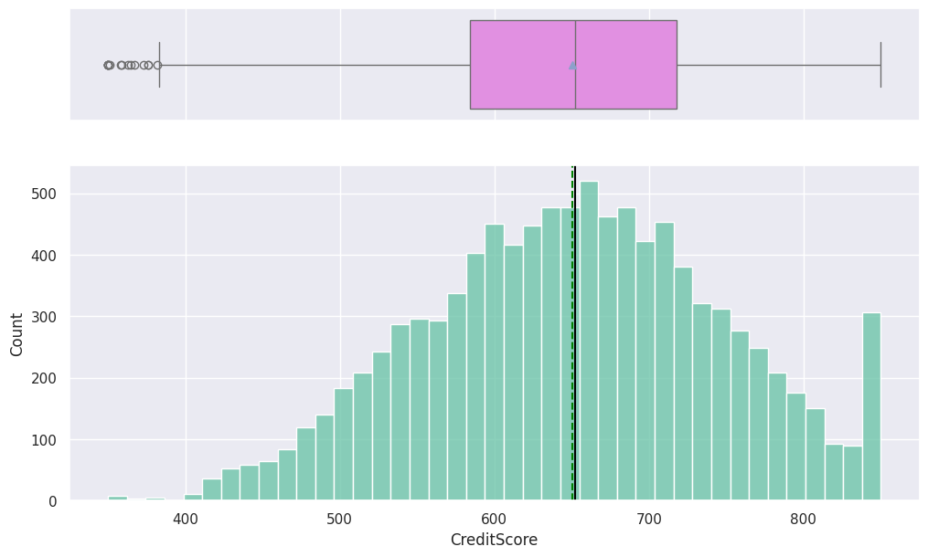

```python
# Observations on CreditScore
histogram_boxplot(dataset, "CreditScore")
```

Observations - the credit score distribution is normal distribution, with a medium of 650, there are some outliers at the lower end, they are few and we might now treat them.

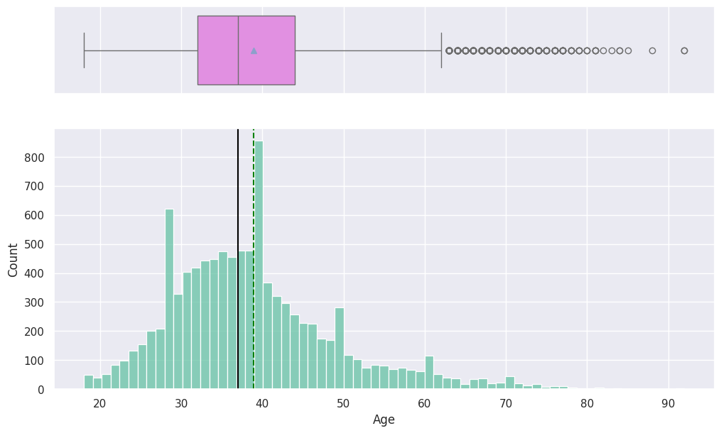

```python
# Observations on Age
histogram_boxplot(dataset, "Age")
```

Observations - the age distribution is not normal distribution, with a average of 39 years, there are some outliers at the right end, they are few and we might now treat them.

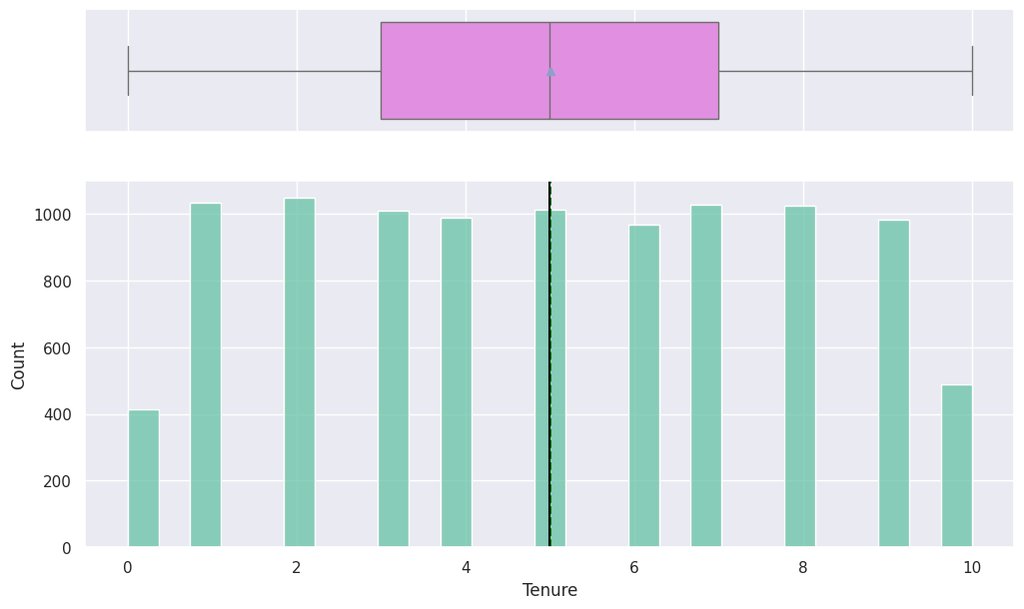

```python
# Observations on Tenure
histogram_boxplot(dataset, "Tenure")
```

Observations - the tenure distribution is not normal distribution, with a average of 5 years, there are no outliers.

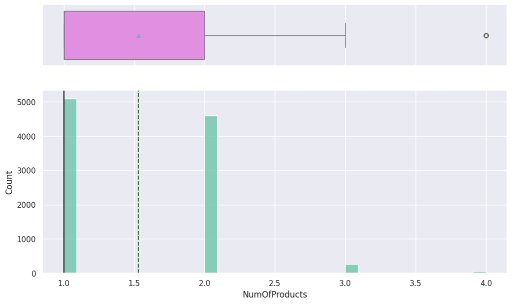

```python
# Observations on NumOfProducts
histogram_boxplot(dataset, "NumOfProducts")
```

Observations - the NumOfProducts distribution is not normal distribution, with a average of 1.5 there are some outliers at the right end, they are few and we might now treat them.

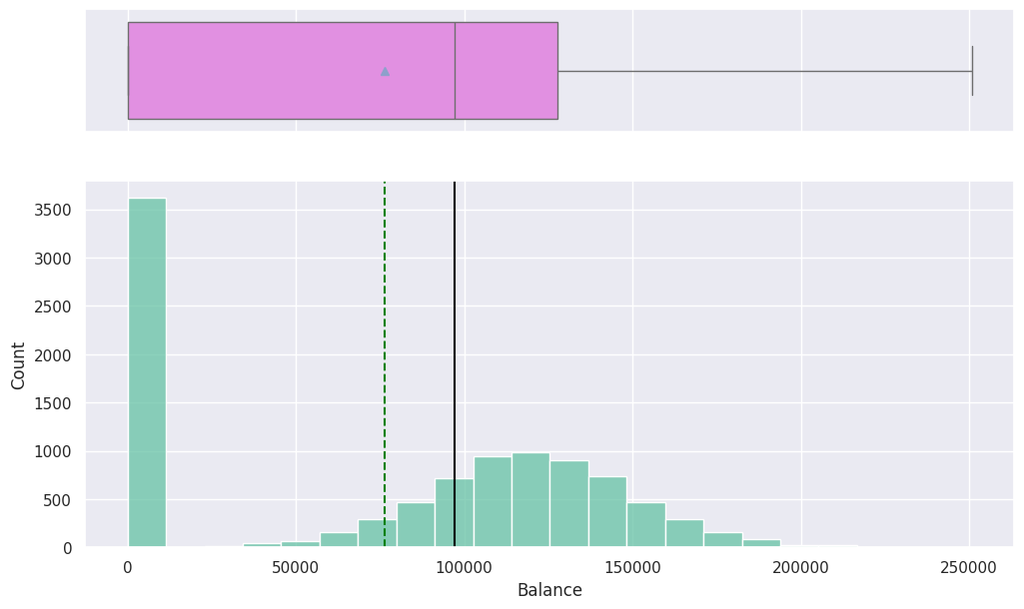

```python
# Observations on Balance
histogram_boxplot(dataset, "Balance")
```

Observations - the balance distribution is not normal distribution, with a average of 76,485.89 balance , there are no outliers.

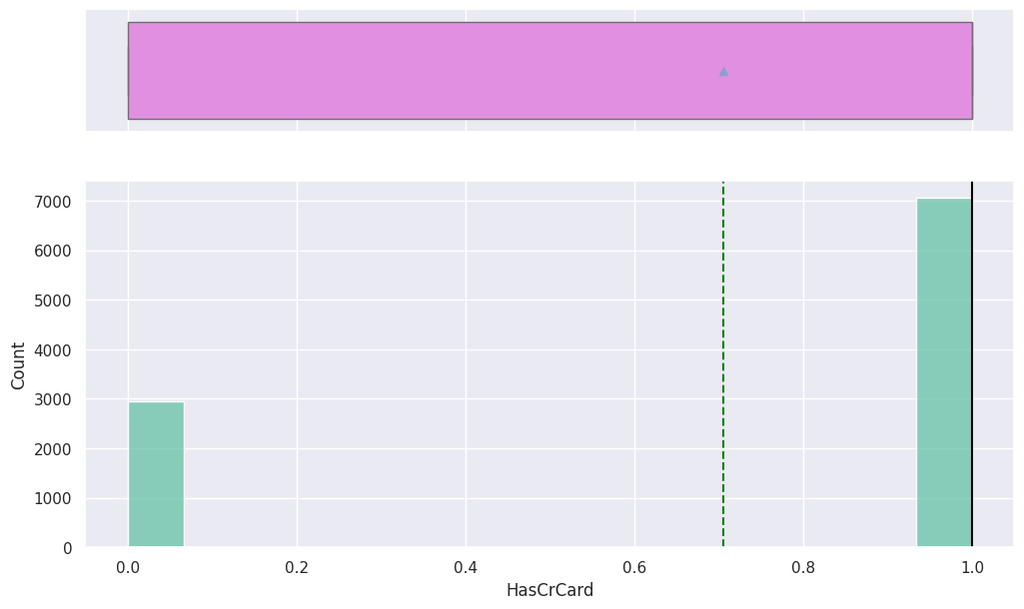

```python
# Observations on HasCrCard
histogram_boxplot(dataset, "HasCrCard")
```

Observations - the has card distribution is not normal distribution, with a average of 70.55 , there are no outliers.

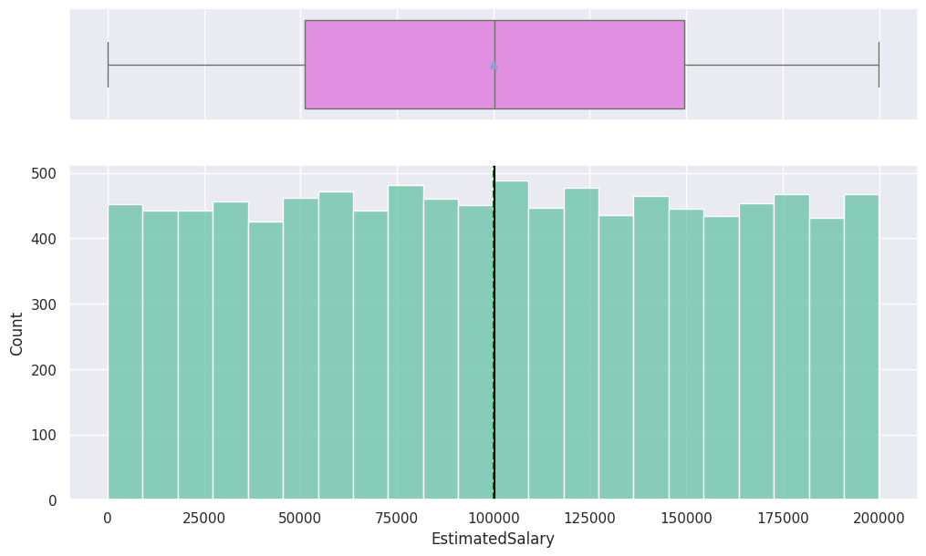

```python
# Observations on EstimatedSalary
histogram_boxplot(dataset, "EstimatedSalary")
```

Observations - the estimated salary distribution is mostly uniform distribution, with a average of 100,090, there are no outliers.

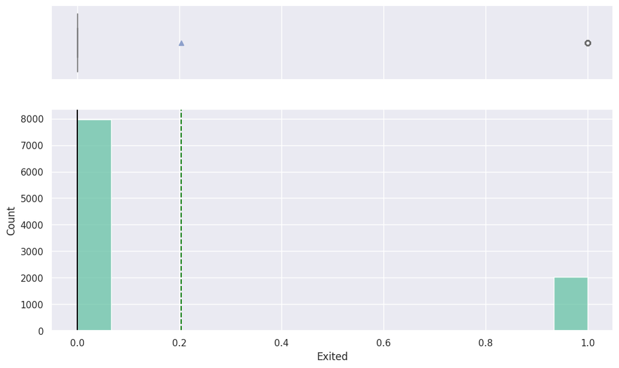

```python
# Observations on Exited
histogram_boxplot(dataset, "Exited")
```

Observations - the exited is a binary variable and shows that 20% customers are exited.

### Obseration of categorical variables

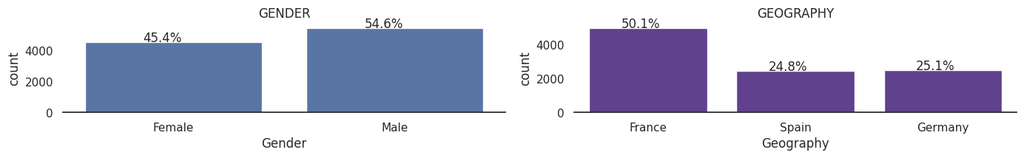

```python
cat_cols = ['Gender', 'Geography']
# Making a list of all categorical variables

plt.figure(figsize=(14,17))

sns.set_theme(style="white")
for i, variable in enumerate(cat_cols):
                     plt.subplot(9,2,i+1)
                     order = dataset[variable].value_counts(ascending=False).index
                     sns.set_palette('twilight_shifted')
                     ax=sns.countplot(x=dataset[variable], data=dataset )
                     sns.despine(top=True,right=True,left=True)
                     for p in ax.patches:
                           percentage = '{:.1f}%'.format(100 * p.get_height()/len(dataset[variable]))
                           x = p.get_x() + p.get_width() / 2 - 0.05
                           y = p.get_y() + p.get_height()
                           plt.annotate(percentage, (x, y),ha='center')
                     plt.tight_layout()
                     plt.title(cat_cols[i].upper())
```

Observation - there is not much differece between male and female ratio, there are 50% customers from France and other two Germany and Spain contribute near about 25% each

## Bivariate analysis

### Observation on bivariate

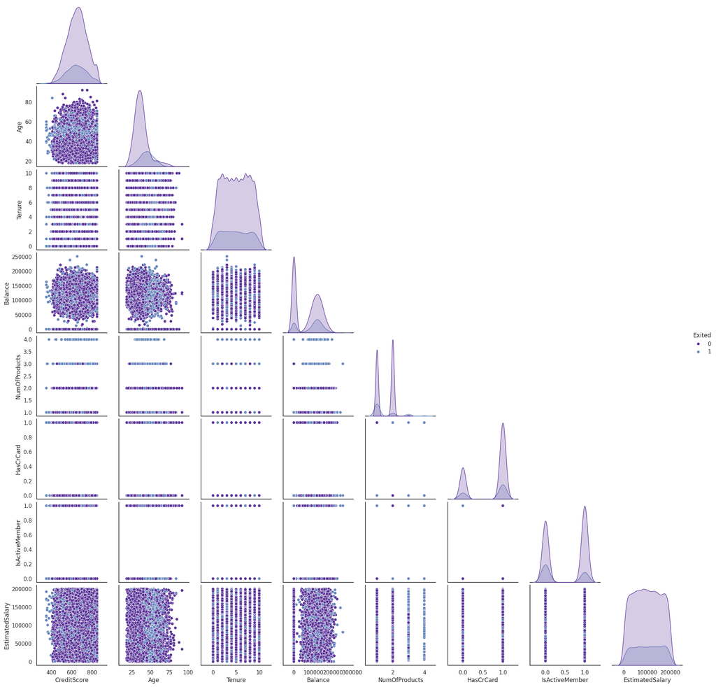

```python
sns.pairplot(dataset, hue="Exited", corner=True)
```

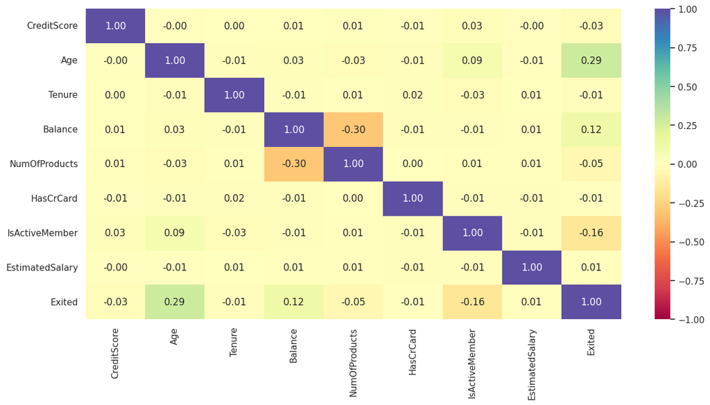

```python
plt.figure(figsize=(15, 7))
sns.heatmap(dataset.corr(), annot=True, vmin=-1, vmax=1, fmt=".2f", cmap="Spectral")
plt.show()
```

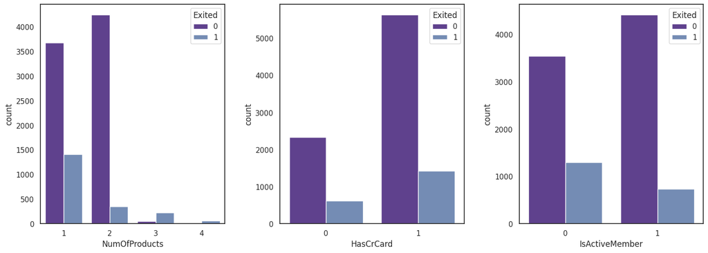

```python
_, ax = plt.subplots(1, 3, figsize=(18, 6))
plt.subplots_adjust(wspace=0.3)
sns.countplot(x = "NumOfProducts", hue="Exited", data = dataset, ax= ax[0])
sns.countplot(x = "HasCrCard", hue="Exited", data = dataset, ax = ax[1])
sns.countplot(x = "IsActiveMember", hue="Exited", data = dataset, ax = ax[2])
```

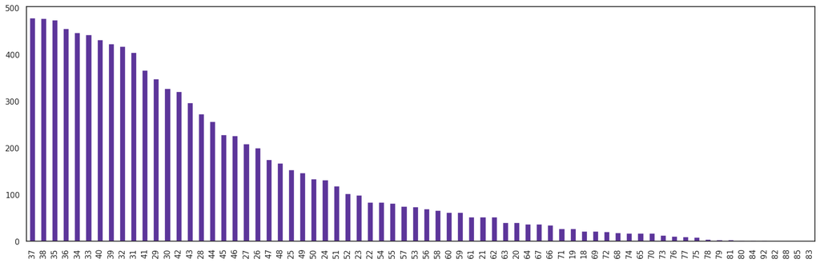

```python
dataset["Age"].value_counts().plot.bar(figsize=(20,6))
```

Observations - most of the customers are concentrated from 30-40 years

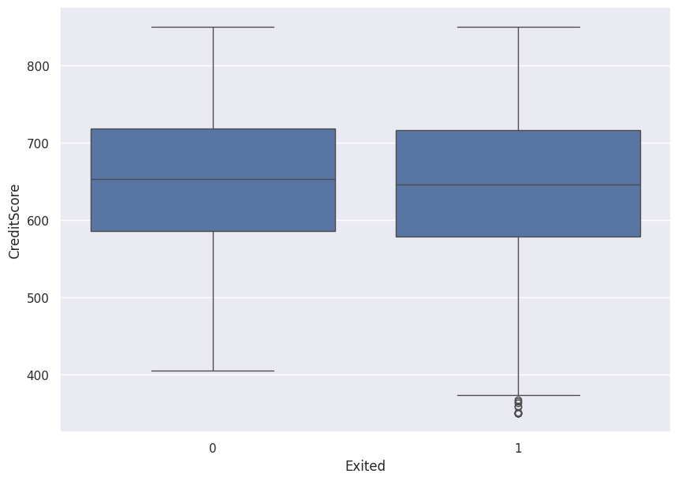

```python
sns.set(rc={"figure.figsize": (10, 7)})
sns.boxplot(x="Exited", y="CreditScore", data=dataset, orient="vertical")
```

Observation - credit score does not show any dependance with exited or not exited customer

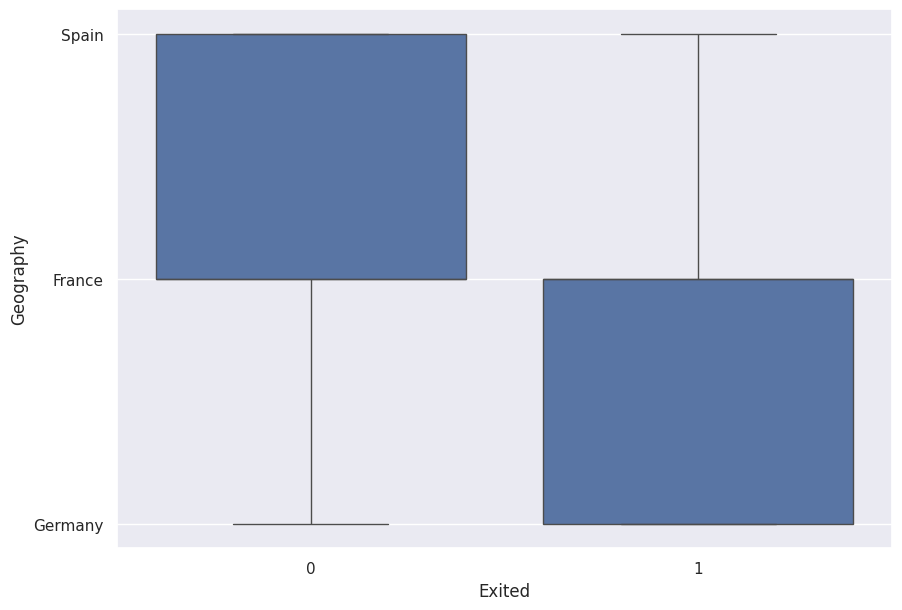

```python
sns.set(rc={"figure.figsize": (10, 7)})
sns.boxplot(x="Exited", y="Geography", data=dataset, orient="vertical")
```

Observation - most of the exited cusomers are from Germany

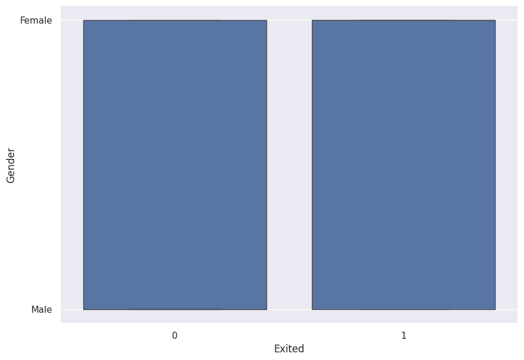

```python
sns.set(rc={"figure.figsize": (10, 7)})
sns.boxplot(x="Exited", y="Gender", data=dataset, orient="vertical")
```

Observation - Gender does not show any difference with exited feature

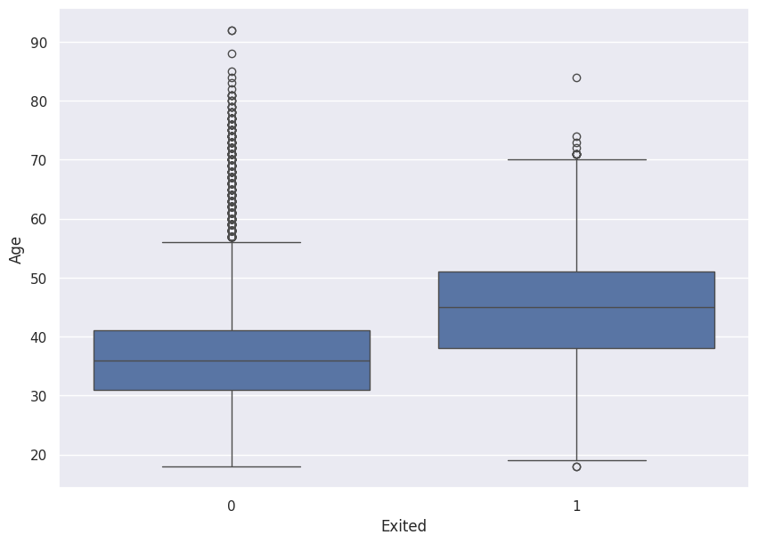

```python
sns.set(rc={"figure.figsize": (10, 7)})
sns.boxplot(x="Exited", y="Age", data=dataset, orient="vertical")
```

Observation - most oft he exited customers are from 40-50 age group

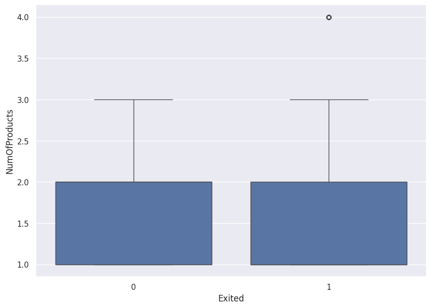

```python
sns.set(rc={"figure.figsize": (10, 7)})
sns.boxplot(x="Exited", y="NumOfProducts", data=dataset, orient="vertical")
```

Observation - no. of products relation with exited does not show nay diffrence.

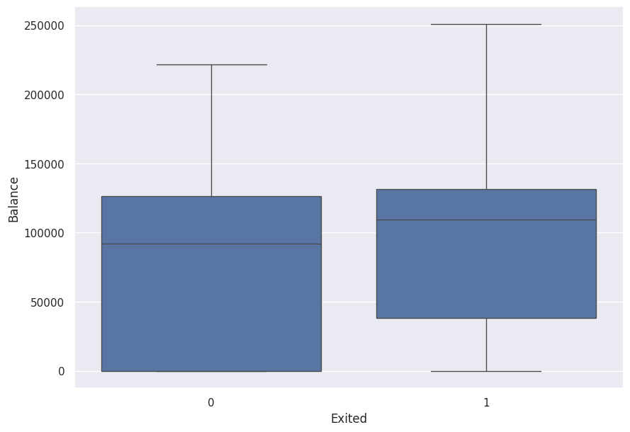

```python
sns.set(rc={"figure.figsize": (10, 7)})
sns.boxplot(x="Exited", y="Balance", data=dataset, orient="vertical")
```

Observation - Exited customers shows a bit higher balance

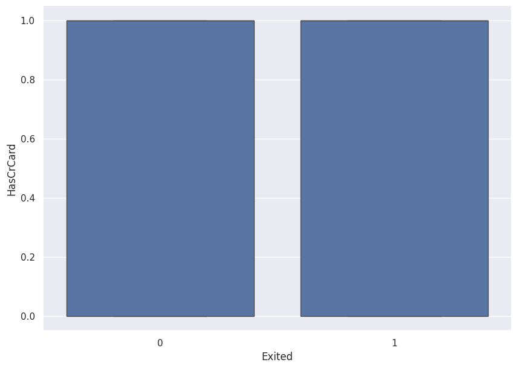

```python
sns.set(rc={"figure.figsize": (10, 7)})
sns.boxplot(x="Exited", y="HasCrCard", data=dataset, orient="vertical")
```

Observation - has credit card does not show any relation with exited

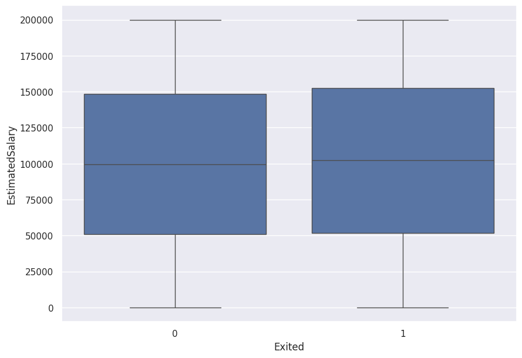

```python
sns.set(rc={"figure.figsize": (10, 7)})
sns.boxplot(x="Exited", y="EstimatedSalary", data=dataset, orient="vertical")
```

Observation - Estimated salary does nor show any difference on exited feature.

```python
## Converting the data type of categorical features to 'category'

cat_cols = ['Gender', 'Geography']

dataset[cat_cols] = dataset[cat_cols].astype('category')
dataset.info()
```

```
<class 'pandas.core.frame.DataFrame'>
RangeIndex: 10000 entries, 0 to 9999
Data columns (total 11 columns):
 #   Column           Non-Null Count  Dtype
---  ------           --------------  -----
 0   CreditScore      10000 non-null  int64
 1   Geography        10000 non-null  category
 2   Gender           10000 non-null  category
 3   Age              10000 non-null  int64
 4   Tenure           10000 non-null  int64
 5   Balance          10000 non-null  float64
 6   NumOfProducts    10000 non-null  int64
 7   HasCrCard        10000 non-null  int64
 8   IsActiveMember   10000 non-null  int64
 9   EstimatedSalary  10000 non-null  float64
 10  Exited           10000 non-null  int64
dtypes: category(2), float64(2), int64(7)
memory usage: 723.0 KB
```

```python
dataset.describe(include=['category']).T
```

|  | count | unique | top | freq |
| --- | --- | --- | --- | --- |
| Geography | 10000 | 3 | France | 5014 |
| Gender | 10000 | 2 | Male | 5457 |

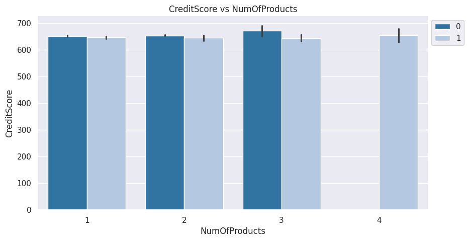

```python
plt.figure(figsize=(10,5))
sns.set_palette(sns.color_palette("tab20", 8))

sns.barplot(y='CreditScore',x='NumOfProducts',hue='Exited',data=dataset)
sns.despine(top=True,right=True,left=True) # to remove side line from graph
plt.legend(bbox_to_anchor=(1.00, 1))
plt.title('CreditScore vs NumOfProducts')
```

Observation - there is no strong relation witn credit scrore and no. of products

## Data Preprocessing

- Missing value treatment
- Feature engineering (if needed)
- Outlier detection and treatment (if needed)
- Preparing data for modeling
- Any other preprocessing steps (if needed)

Observation - There no missing values in dataset, there is not much outliers as well and they might be valid, so we will not treat them.

```python
dataset.info()
```

```
<class 'pandas.core.frame.DataFrame'>
RangeIndex: 10000 entries, 0 to 9999
Data columns (total 11 columns):
 #   Column           Non-Null Count  Dtype
---  ------           --------------  -----
 0   CreditScore      10000 non-null  int64
 1   Geography        10000 non-null  category
 2   Gender           10000 non-null  category
 3   Age              10000 non-null  int64
 4   Tenure           10000 non-null  int64
 5   Balance          10000 non-null  float64
 6   NumOfProducts    10000 non-null  int64
 7   HasCrCard        10000 non-null  int64
 8   IsActiveMember   10000 non-null  int64
 9   EstimatedSalary  10000 non-null  float64
 10  Exited           10000 non-null  int64
dtypes: category(2), float64(2), int64(7)
memory usage: 723.0 KB
```

```python
dataset.head()
```

|  | CreditScore | Geography | Gender | Age | Tenure | Balance | NumOfProducts | HasCrCard | IsActiveMember | EstimatedSalary | Exited |
| --- | --- | --- | --- | --- | --- | --- | --- | --- | --- | --- | --- |
| 0 | 619 | France | Female | 42 | 2 | 0.00 | 1 | 1 | 1 | 101348.88 | 1 |
| 1 | 608 | Spain | Female | 41 | 1 | 83807.86 | 1 | 0 | 1 | 112542.58 | 0 |
| 2 | 502 | France | Female | 42 | 8 | 159660.80 | 3 | 1 | 0 | 113931.57 | 1 |
| 3 | 699 | France | Female | 39 | 1 | 0.00 | 2 | 0 | 0 | 93826.63 | 0 |
| 4 | 850 | Spain | Female | 43 | 2 | 125510.82 | 1 | 1 | 1 | 79084.10 | 0 |

```python
# get dummies for categorical variables
dataset = pd.get_dummies(df, columns=['Geography', 'Gender'], drop_first=True)
```

```python
dataset.head()
```

|  | RowNumber | CustomerId | Surname | CreditScore | Age | Tenure | Balance | NumOfProducts | HasCrCard | IsActiveMember | EstimatedSalary | Exited | Geography_Germany | Geography_Spain | Gender_Male |
| --- | --- | --- | --- | --- | --- | --- | --- | --- | --- | --- | --- | --- | --- | --- | --- |
| 0 | 1 | 15634602 | Hargrave | 619 | 42 | 2 | 0.00 | 1 | 1 | 1 | 101348.88 | 1 | 0 | 0 | 0 |
| 1 | 2 | 15647311 | Hill | 608 | 41 | 1 | 83807.86 | 1 | 0 | 1 | 112542.58 | 0 | 0 | 1 | 0 |
| 2 | 3 | 15619304 | Onio | 502 | 42 | 8 | 159660.80 | 3 | 1 | 0 | 113931.57 | 1 | 0 | 0 | 0 |
| 3 | 4 | 15701354 | Boni | 699 | 39 | 1 | 0.00 | 2 | 0 | 0 | 93826.63 | 0 | 0 | 0 | 0 |
| 4 | 5 | 15737888 | Mitchell | 850 | 43 | 2 | 125510.82 | 1 | 1 | 1 | 79084.10 | 0 | 0 | 1 | 0 |

```python
dataset.drop(["RowNumber", "CustomerId", "Surname"], axis=1, inplace=True)
```

```python
dataset.head()
```

|  | CreditScore | Age | Tenure | Balance | NumOfProducts | HasCrCard | IsActiveMember | EstimatedSalary | Exited | Geography_Germany | Geography_Spain | Gender_Male |
| --- | --- | --- | --- | --- | --- | --- | --- | --- | --- | --- | --- | --- |
| 0 | 619 | 42 | 2 | 0.00 | 1 | 1 | 1 | 101348.88 | 1 | 0 | 0 | 0 |
| 1 | 608 | 41 | 1 | 83807.86 | 1 | 0 | 1 | 112542.58 | 0 | 0 | 1 | 0 |
| 2 | 502 | 42 | 8 | 159660.80 | 3 | 1 | 0 | 113931.57 | 1 | 0 | 0 | 0 |
| 3 | 699 | 39 | 1 | 0.00 | 2 | 0 | 0 | 93826.63 | 0 | 0 | 0 | 0 |
| 4 | 850 | 43 | 2 | 125510.82 | 1 | 1 | 1 | 79084.10 | 0 | 0 | 1 | 0 |

```python
dataset.info()
```

```
<class 'pandas.core.frame.DataFrame'>
RangeIndex: 10000 entries, 0 to 9999
Data columns (total 12 columns):
 #   Column             Non-Null Count  Dtype
---  ------             --------------  -----
 0   CreditScore        10000 non-null  int64
 1   Age                10000 non-null  int64
 2   Tenure             10000 non-null  int64
 3   Balance            10000 non-null  float64
 4   NumOfProducts      10000 non-null  int64
 5   HasCrCard          10000 non-null  int64
 6   IsActiveMember     10000 non-null  int64
 7   EstimatedSalary    10000 non-null  float64
 8   Exited             10000 non-null  int64
 9   Geography_Germany  10000 non-null  uint8
 10  Geography_Spain    10000 non-null  uint8
 11  Gender_Male        10000 non-null  uint8
dtypes: float64(2), int64(7), uint8(3)
memory usage: 732.5 KB
```

```python
#convert data type to float
dataset = dataset.astype('float32')
```

```python
dataset.info()
```

```
<class 'pandas.core.frame.DataFrame'>
RangeIndex: 10000 entries, 0 to 9999
Data columns (total 12 columns):
 #   Column             Non-Null Count  Dtype
---  ------             --------------  -----
 0   CreditScore        10000 non-null  float32
 1   Age                10000 non-null  float32
 2   Tenure             10000 non-null  float32
 3   Balance            10000 non-null  float32
 4   NumOfProducts      10000 non-null  float32
 5   HasCrCard          10000 non-null  float32
 6   IsActiveMember     10000 non-null  float32
 7   EstimatedSalary    10000 non-null  float32
 8   Exited             10000 non-null  float32
 9   Geography_Germany  10000 non-null  float32
 10  Geography_Spain    10000 non-null  float32
 11  Gender_Male        10000 non-null  float32
dtypes: float32(12)
memory usage: 468.9 KB
```

```python
dataset.head()
```

|  | CreditScore | Age | Tenure | Balance | NumOfProducts | HasCrCard | IsActiveMember | EstimatedSalary | Exited | Geography_Germany | Geography_Spain | Gender_Male |
| --- | --- | --- | --- | --- | --- | --- | --- | --- | --- | --- | --- | --- |
| 0 | 619.0 | 42.0 | 2.0 | 0.000000 | 1.0 | 1.0 | 1.0 | 101348.882812 | 1.0 | 0.0 | 0.0 | 0.0 |
| 1 | 608.0 | 41.0 | 1.0 | 83807.859375 | 1.0 | 0.0 | 1.0 | 112542.578125 | 0.0 | 0.0 | 1.0 | 0.0 |
| 2 | 502.0 | 42.0 | 8.0 | 159660.796875 | 3.0 | 1.0 | 0.0 | 113931.570312 | 1.0 | 0.0 | 0.0 | 0.0 |
| 3 | 699.0 | 39.0 | 1.0 | 0.000000 | 2.0 | 0.0 | 0.0 | 93826.632812 | 0.0 | 0.0 | 0.0 | 0.0 |
| 4 | 850.0 | 43.0 | 2.0 | 125510.820312 | 1.0 | 1.0 | 1.0 | 79084.101562 | 0.0 | 0.0 | 1.0 | 0.0 |

```python
#getting the features and labels and finally splitting the test and train data.
X = dataset.drop('Exited', axis=1)
y = dataset['Exited'].values
```

```python
#Splitting the training and test set
X_train, X_test, y_train, y_test = train_test_split(X, y, stratify = y, test_size = 0.10, random_state = 42)
```

```python
scaler = StandardScaler()
```

```python
X_train.shape
X_test.shape
```

```
(1000, 11)
```

```python
X_train.head()
```

|  | CreditScore | Age | Tenure | Balance | NumOfProducts | HasCrCard | IsActiveMember | EstimatedSalary | Geography_Germany | Geography_Spain | Gender_Male |
| --- | --- | --- | --- | --- | --- | --- | --- | --- | --- | --- | --- |
| 673 | 640.0 | 32.0 | 6.0 | 118879.351562 | 2.0 | 1.0 | 1.0 | 19131.710938 | 0.0 | 1.0 | 0.0 |
| 7709 | 598.0 | 64.0 | 1.0 | 62979.929688 | 1.0 | 1.0 | 1.0 | 152273.562500 | 0.0 | 1.0 | 0.0 |
| 6100 | 796.0 | 30.0 | 2.0 | 137262.703125 | 2.0 | 1.0 | 0.0 | 62905.289062 | 0.0 | 0.0 | 1.0 |
| 8469 | 720.0 | 71.0 | 5.0 | 183135.390625 | 2.0 | 1.0 | 1.0 | 197688.500000 | 0.0 | 0.0 | 1.0 |
| 8563 | 578.0 | 45.0 | 1.0 | 148600.906250 | 1.0 | 1.0 | 0.0 | 143397.140625 | 0.0 | 0.0 | 1.0 |

```python
y_train.shape
y_test.shape
```

```
(1000,)
```

```python
X_train= scaler.fit_transform(X_train)
X_test = scaler.transform(X_test)
```

```python
target_scaler = preprocessing.StandardScaler()
y_train = target_scaler.fit_transform(y_train.reshape(-1,1))
y_test = target_scaler.transform(y_test.reshape(-1,1))
```

## Model Building

### Model Evaluation Criterion

we will primarily consider the R-squared (R2) value as a primary metric, as it indicates the proportion of the variance in the dependent variable that is predictable from the independent variable(s). A higher R2 value generally indicates a better fit for the model to the data. However, in cases where R2 is not applicable or provides extreme values (especially negative values far from 0), we might consider other metrics like Mean Squared Error (MSE) and the context of the loss values to guide the ranking.

### Model Building: Neural Network

### Model Building: Neural Network model with SGD

```python
backend.clear_session()
#Fixing the seed for random number generators so that we can ensure we receive the same output everytime
np.random.seed(42)
import random
random.seed(42)
tf.random.set_seed(42)
```

```python
def build_model_SGD():
  ## Initializing the ANN
  model = Sequential()
  input_layer = Dense(16, input_shape=(X_train.shape[1],),activation='relu')
  model.add(input_layer)
  hidden_layer = Dense(8, activation='relu');
  model.add(hidden_layer)
  output_layer = Dense(1, activation='sigmoid')
  model.add(output_layer)

  # Defining the optimizer
  optimizer = tf.keras.optimizers.SGD(0.001)  # Defining the optimizer
  # Compiling the model
  model.compile(loss='binary_crossentropy',
              optimizer=optimizer,
              metrics=['mse'])  # Defining the loss function, optimizer and metrices

  return model
```

```python
#Getting the model summary. We are uaing standalone keras to build our model
model_SGD = build_model_SGD()
model_SGD.summary()
```

```
Model: "sequential"
_________________________________________________________________
 Layer (type)                Output Shape              Param #
=================================================================
 dense (Dense)               (None, 16)                192

 dense_1 (Dense)             (None, 8)                 136

 dense_2 (Dense)             (None, 1)                 9

=================================================================
Total params: 337 (1.32 KB)
Trainable params: 337 (1.32 KB)
Non-trainable params: 0 (0.00 Byte)
_________________________________________________________________
```

```python
#Definign the number of epochs
EPOCHS = 35
#fitting the model
history = model_SGD.fit(X_train, y_train,epochs=EPOCHS, validation_split = 0.2, verbose=1)
```

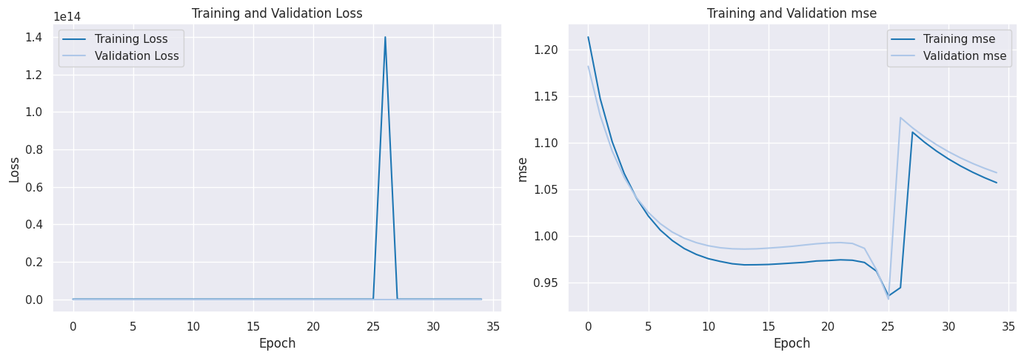

```python
from matplotlib import pyplot as plt

# Plotting training and validation loss
plt.figure(figsize=(14, 5))
plt.subplot(1, 2, 1)  # 1 row, 2 columns, 1st subplot
plt.title('Training and Validation Loss')
plt.plot(history.history['loss'], label='Training Loss')
plt.plot(history.history['val_loss'], label='Validation Loss')
plt.xlabel('Epoch')
plt.ylabel('Loss')
plt.legend()

# Plotting training and validation accuracy
plt.subplot(1, 2, 2)  # 1 row, 2 columns, 2nd subplot
plt.title('Training and Validation mse')
plt.plot(history.history['mse'], label='Training mse')
plt.plot(history.history['val_mse'], label='Validation mse')
plt.xlabel('Epoch')
plt.ylabel('mse')
plt.legend()

plt.tight_layout()  # Adjusts subplot params so that subplots are nicely fit in the figure area.
plt.show()
```

```python
loss, mse = model_SGD.evaluate(X_test, y_test)
print(f"Loss: {loss}")
print(f"mse: {mse}")
```

```
Loss: 0.2801664173603058
mse: 1.0596612691879272
```

```python
#Lets Print the predicted
test_predictions_SGD = model_SGD.predict(X_test)
y_pred_SGD=target_scaler.inverse_transform(test_predictions_SGD.reshape(-1, 1))
```

```python
sklearn.metrics.r2_score(target_scaler.inverse_transform(y_test.reshape(-1, 1)),y_pred_SGD)
```

```
-0.058372729110230503
```

### Model Building: Neural Network model with Adam Optimizer

```python
backend.clear_session()
#Fixing the seed for random number generators so that we can ensure we receive the same output everytime
np.random.seed(42)
import random
random.seed(42)
tf.random.set_seed(42)
```

```python
def build_model_adam_only():
  model = Sequential()
  model.add(Dense(16, input_shape=(X_train.shape[1],), activation='relu', kernel_initializer='he_uniform'))
  model.add(Dense(8, activation='relu', kernel_initializer='he_uniform'))
  #model.add(Dense(16, activation='relu', kernel_initializer='he_uniform'))
  model.add(Dense(1, activation='sigmoid'))

  optimizer = tf.keras.optimizers.Adam(0.001)
  model.compile(loss = 'binary_crossentropy', optimizer=optimizer, metrics=['mse'])

  return model
```

```python
#Getting the model summary. We are uaing standalone keras to build our model
model_adam_only = build_model_adam_only()
model_adam_only.summary()
```

```
Model: "sequential"
_________________________________________________________________
 Layer (type)                Output Shape              Param #
=================================================================
 dense (Dense)               (None, 16)                192

 dense_1 (Dense)             (None, 8)                 136

 dense_2 (Dense)             (None, 1)                 9

=================================================================
Total params: 337 (1.32 KB)
Trainable params: 337 (1.32 KB)
Non-trainable params: 0 (0.00 Byte)
_________________________________________________________________
```

```python
#Definign the number of epochs
EPOCHS = 35
#fitting the model
history = model_adam_only.fit(X_train, y_train,epochs=EPOCHS, validation_split = 0.2, verbose=1)
```

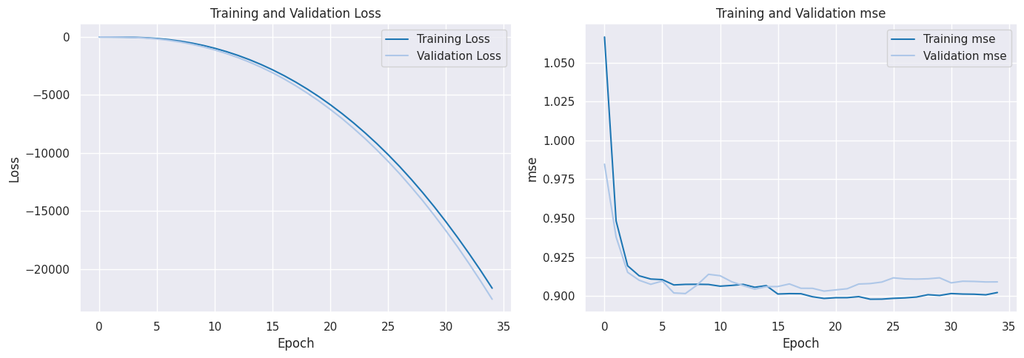

```python
from matplotlib import pyplot as plt

# Plotting training and validation loss
plt.figure(figsize=(14, 5))
plt.subplot(1, 2, 1)  # 1 row, 2 columns, 1st subplot
plt.title('Training and Validation Loss')
plt.plot(history.history['loss'], label='Training Loss')
plt.plot(history.history['val_loss'], label='Validation Loss')
plt.xlabel('Epoch')
plt.ylabel('Loss')
plt.legend()

# Plotting training and validation accuracy
plt.subplot(1, 2, 2)  # 1 row, 2 columns, 2nd subplot
plt.title('Training and Validation mse')
plt.plot(history.history['mse'], label='Training mse')
plt.plot(history.history['val_mse'], label='Validation mse')
plt.xlabel('Epoch')
plt.ylabel('mse')
plt.legend()

plt.tight_layout()  # Adjusts subplot params so that subplots are nicely fit in the figure area.
plt.show()
```

```python
loss, mse = model_adam_only.evaluate(X_test, y_test)
print("loss : ", loss)
print("mse : ", mse)
```

```
loss :  -21279.80859375
mse :  0.926891028881073
```

```python
#Lets Print the predicted
test_predictions_adam_only=model_adam_only.predict(X_test)
y_pred_adam_only=target_scaler.inverse_transform(test_predictions_adam_only.reshape(-1, 1))
```

```python
sklearn.metrics.r2_score(target_scaler.inverse_transform(y_test.reshape(-1, 1)),y_pred_adam_only)
```

```
0.07423596141148447
```

### Model Improvement: Neural Network model with Dropout and Adam optimizer

```python
backend.clear_session()
#Fixing the seed for random number generators so that we can ensure we receive the same output everytime
np.random.seed(42)
import random
random.seed(42)
tf.random.set_seed(42)
```

```python
def build_model_adam_and_dropout():
  # Initializing the model
  model_adam_dropout = Sequential()
  model_adam_dropout.add(Dense(16, input_shape=(X_train.shape[1],), activation='relu', kernel_initializer='he_uniform'))
  # Adding Dropout with 10%
  model_adam_dropout.add(Dropout(0.2))
  model_adam_dropout.add(Dense(8, input_shape=(X_train.shape[1],), activation='relu', kernel_initializer='he_uniform'))
  # Adding the output layer with one neuron and linear as activation
  model_adam_dropout.add(Dense(1, activation='sigmoid'))

  optimizer = tf.keras.optimizers.Adam(0.001)
  model_adam_dropout.compile(loss='binary_crossentropy', optimizer=optimizer, metrics=['mse'])

  return model_adam_dropout
```

```python
#Getting the model summary. We are uaing standalone keras to build our model
model_adam_dropout = build_model_adam_and_dropout()
model_adam_dropout.summary()
```

```
Model: "sequential"
_________________________________________________________________
 Layer (type)                Output Shape              Param #
=================================================================
 dense (Dense)               (None, 16)                192

 dropout (Dropout)           (None, 16)                0

 dense_1 (Dense)             (None, 8)                 136

 dense_2 (Dense)             (None, 1)                 9

=================================================================
Total params: 337 (1.32 KB)
Trainable params: 337 (1.32 KB)
Non-trainable params: 0 (0.00 Byte)
_________________________________________________________________
```

```python
#Definign the number of epochs
EPOCHS = 35
#fitting the model
history = model_adam_dropout.fit(X_train, y_train,epochs=EPOCHS, validation_split = 0.2, verbose=1)
```

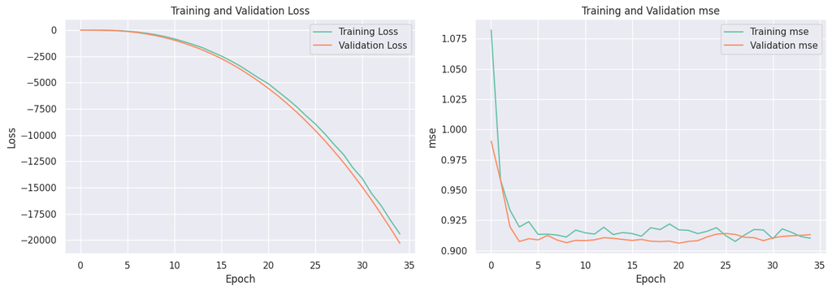

```python
from matplotlib import pyplot as plt

# Plotting training and validation loss
plt.figure(figsize=(14, 5))
plt.subplot(1, 2, 1)  # 1 row, 2 columns, 1st subplot
plt.title('Training and Validation Loss')
plt.plot(history.history['loss'], label='Training Loss')
plt.plot(history.history['val_loss'], label='Validation Loss')
plt.xlabel('Epoch')
plt.ylabel('Loss')
plt.legend()

# Plotting training and validation accuracy
plt.subplot(1, 2, 2)  # 1 row, 2 columns, 2nd subplot
plt.title('Training and Validation mse')
plt.plot(history.history['mse'], label='Training mse')
plt.plot(history.history['val_mse'], label='Validation mse')
plt.xlabel('Epoch')
plt.ylabel('mse')
plt.legend()

plt.tight_layout()  # Adjusts subplot params so that subplots are nicely fit in the figure area.
plt.show()
```

```python
loss, mse = model_adam_dropout.evaluate(X_test, y_test)
print("loss : ", loss)
print("mse : ", mse)
```

```
loss :  -19133.1328125
mse :  0.9353367686271667
```

```python
#Lets Print the predicted
test_predictions_adam_dropout=model_adam_dropout.predict(X_test)
y_pred_adam_dropout=target_scaler.inverse_transform(test_predictions_adam_dropout.reshape(-1, 1))
```

```python
sklearn.metrics.r2_score(target_scaler.inverse_transform(y_test.reshape(-1, 1)),y_pred_adam_dropout)
```

```
0.06580047636763331
```

### Model Improvement: Neural Network model with Hyperparameter tuning and Adam optimizer

```python
backend.clear_session()
np.random.seed(42)
import random
random.seed(42)
tf.random.set_seed(42)
```

```python
# Adjust the model-building function to accept hyperparameters
def build_model(learning_rate=0.001):
    model = Sequential()
    model.add(Dense(18, input_shape=(X_train.shape[1],), activation='relu'))
    model.add(Dense(8, activation='relu'))
    model.add(Dense(1, activation='sigmoid'))
    optimizer = Adam(learning_rate=learning_rate)
    model.compile(loss='binary_crossentropy', optimizer=optimizer, metrics=['mse'])
    return model

# Function for hyperparameter tuning
def model_grid_search(X_train, y_train, fit_params=None):
    model = KerasRegressor(model=build_model, verbose=0)
    param_grid = {
        'model__learning_rate': [0.01, 0.001],
        'epochs': [4, 6],  # Reduced for demonstration
        'batch_size': [128, 256]
    }
    grid = GridSearchCV(estimator=model, param_grid=param_grid, n_jobs=-1, cv=3)
    #grid_result = grid.fit(X_train, y_train, **(fit_params if fit_params else {}))
    grid_result = grid.fit(X_train, y_train, epochs=10, batch_size=32, validation_split=0.2)
    return grid_result
```

```python
early_stopping = EarlyStopping(monitor='val_loss', patience=5)
fit_params = {"callbacks": [early_stopping]}
grid_result = model_grid_search(X_train, y_train, fit_params=fit_params)
```

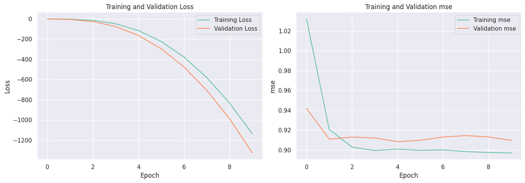

```python
from matplotlib import pyplot

# Assuming grid_result is the result from your GridSearchCV execution
best_estimator = grid_result.best_estimator_  # This gets the best estimator

# To get the actual Keras model, you might directly access it like this:
# This step can vary depending on scikeras version and setup
model_adam_gs = best_estimator.model_

# Now, you can access the history attribute directly from the model object
history = model_adam_gs.history

from matplotlib import pyplot as plt

# Plotting training and validation loss
plt.figure(figsize=(14, 5))
plt.subplot(1, 2, 1)  # 1 row, 2 columns, 1st subplot
plt.title('Training and Validation Loss')
plt.plot(history.history['loss'], label='Training Loss')
plt.plot(history.history['val_loss'], label='Validation Loss')
plt.xlabel('Epoch')
plt.ylabel('Loss')
plt.legend()

# Plotting training and validation accuracy
plt.subplot(1, 2, 2)  # 1 row, 2 columns, 2nd subplot
plt.title('Training and Validation mse')
plt.plot(history.history['mse'], label='Training mse')
plt.plot(history.history['val_mse'], label='Validation mse')
plt.xlabel('Epoch')
plt.ylabel('mse')
plt.legend()

plt.tight_layout()  # Adjusts subplot params so that subplots are nicely fit in the figure area.
plt.show()
```

```python
model_adam_gs.summary()
```

```
Model: "sequential"
_________________________________________________________________
 Layer (type)                Output Shape              Param #
=================================================================
 dense (Dense)               (None, 18)                216

 dense_1 (Dense)             (None, 8)                 152

 dense_2 (Dense)             (None, 1)                 9

=================================================================
Total params: 377 (1.47 KB)
Trainable params: 377 (1.47 KB)
Non-trainable params: 0 (0.00 Byte)
_________________________________________________________________
```

```python
loss, mse = model_adam_gs.evaluate(X_test, y_test)
print("loss : ", loss)
print("mse : ", mse)
```

```
loss :  -1254.55078125
mse :  0.9253644347190857
```

```python
#Lets Print the predicted
test_predictions_adam_gs=model_adam_gs.predict(X_test)
y_pred_adam_gs=target_scaler.inverse_transform(test_predictions_adam_gs.reshape(-1, 1))
```

```python
sklearn.metrics.r2_score(target_scaler.inverse_transform(y_test.reshape(-1, 1)),y_pred_adam_gs)
```

```
0.07576081523431899
```

```python
backend.clear_session()
np.random.seed(42)
import random
random.seed(42)
tf.random.set_seed(42)
```

```python
# Assuming X and y are your features and target variable respectively
X_train, X_test, y_train, y_test = train_test_split(X, y, test_size=0.2, random_state=42)

# Apply SMOTE to balance the classes
smote = SMOTE(random_state=42)
X_train_smote, y_train_smote = smote.fit_resample(X_train, y_train)

X_train_smote= scaler.fit_transform(X_train)
X_test_smote = scaler.transform(X_test)

target_scaler = preprocessing.StandardScaler()
y_train_smote = target_scaler.fit_transform(y_train.reshape(-1,1))
y_test_smote = target_scaler.transform(y_test.reshape(-1,1))
```

```python
# Define your model structure
def build_model_adam_smote(input_shape):
    model = Sequential()
    model.add(Dense(16, input_shape=(input_shape,), activation='relu'))
    model.add(Dense(8, activation='relu'))
    # Assuming a binary classification problem; use 'sigmoid' for the last layer if so
    # For multi-class classification, adjust the activation to 'softmax' and units to the number of classes
    model.add(Dense(1, activation='sigmoid'))  # Update based on your specific problem

    optimizer = tf.keras.optimizers.Adam(0.001)
    # For binary classification, use 'binary_crossentropy' loss
    # For multi-class classification, use 'categorical_crossentropy'
    model.compile(loss='binary_crossentropy', optimizer=optimizer, metrics=['mse'])  # Update metrics if needed

    return model
```

```python
# Build the model
model_adam_smote = build_model_adam_smote(X_train_smote.shape[1])

# Train the model
history = model_adam_smote.fit(X_train_smote, y_train_smote, epochs=35, batch_size=32, validation_split=0.2)

# Evaluate the model
model_adam_smote.evaluate(X_test, y_test)
```

```
[8.35712718963623, 0.5476190447807312]
```

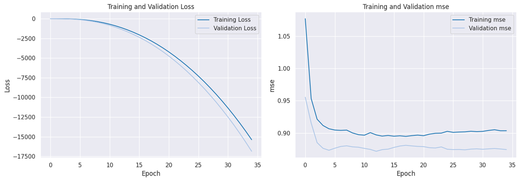

```python
from matplotlib import pyplot as plt

# Plotting training and validation loss
plt.figure(figsize=(14, 5))
plt.subplot(1, 2, 1)  # 1 row, 2 columns, 1st subplot
plt.title('Training and Validation Loss')
plt.plot(history.history['loss'], label='Training Loss')
plt.plot(history.history['val_loss'], label='Validation Loss')
plt.xlabel('Epoch')
plt.ylabel('Loss')
plt.legend()

# Plotting training and validation accuracy
plt.subplot(1, 2, 2)  # 1 row, 2 columns, 2nd subplot
plt.title('Training and Validation mse')
plt.plot(history.history['mse'], label='Training mse')
plt.plot(history.history['val_mse'], label='Validation mse')
plt.xlabel('Epoch')
plt.ylabel('mse')
plt.legend()

plt.tight_layout()  # Adjusts subplot params so that subplots are nicely fit in the figure area.
plt.show()
```

```python
loss, mse = model_adam_smote.evaluate(X_test, y_test)
print("loss : ", loss)
print("mse : ", mse)
```

```
loss :  8.35712718963623
mse :  0.5476190447807312
```

```python
#Lets Print the predicted
test_predictions_adam_smote=model_adam_smote.predict(X_test)
y_pred_adam_smote=target_scaler.inverse_transform(test_predictions_adam_smote.reshape(-1, 1))
```

```python
sklearn.metrics.r2_score(target_scaler.inverse_transform(y_test.reshape(-1, 1)),y_pred_adam_smote)
```

```
-2.467653608819983
```